# U.S. Trade and Macroeconomic Trends (2002–2023)

INST 447 — Track B: End-to-End Pipeline

Authors

Affiliation

Kyle Tabong

University of Maryland

Taylor Hardesty

University of Maryland

Ashrutha Lingampalli

University of Maryland

Published

May 1, 2026

## 1. Introduction

U.S. trade policy and trade flows have been central to political and economic discussions for decades. Despite this, few studies bring together trade balance data and broader macroeconomic indicators like GDP and inflation into a single cohesive analysis spanning more than two decades.

The goal of this project is to answer the following research question:

> **What economic trends were observed from 2002 to 2023, and how did changes in U.S. trade impact broader macroeconomic conditions?**

We focus specifically on how shifts in U.S. imports and exports correspond with changes in GDP growth and inflation over the 2002–2023 period. Trade is a major driver of economic performance, and understanding the relationship between trade flows and macroeconomic variables has both academic and policy value.

This project fits **Track B** of the INST 447 project because rather than collecting new primary data, we apply an end-to-end pipeline to existing publicly available datasets to answer an analytical question that no single source has addressed.

## 3. Methodology

### 3.1 Data Sources

This project draws on two primary data sources, both freely accessible via API and well-suited for programmatic data collection in Python.

**FRED API (Federal Reserve Bank of St. Louis)**

FRED provides GDP, CPI, and U.S. trade balance data through a well-documented REST API. Data goes back decades, is updated regularly, and is free to access with a simple API key registration. We use the `fredapi` Python library, which returns data directly as pandas Series objects. Key series include:

- `GDPC1` — Real GDP (quarterly, billions of chained 2017 dollars)
- `CPIAUCSL` — Consumer Price Index (monthly)
- `BOPGTB` — U.S. Goods Trade Balance (monthly, millions of dollars)

**World Bank Open Data API**

The World Bank API provides country-level trade data with no API key required. We pull U.S. trade as a share of GDP using indicator `NE.TRD.GNFS.ZS` via the `wbgapi` Python library.

### 3.2 Pipeline Overview

Our pipeline follows the end-to-end workflow taught in INST 447:

1. **Data Ingestion** — Pull all four datasets from APIs and save as CSV files
2. **Data Cleaning** — Standardize each dataset to annual frequency
3. **Data Merging** — Merge all four datasets on year using pandas inner joins
4. **Analysis** — Run correlation, regression, and ANOVA tests
5. **Visualization** — Produce line charts, bar charts, scatter plots, and a correlation heatmap
6. **Communication** — Package results in this Quarto manuscript

### 3.3 Data Cleaning Decisions

Each dataset arrives at a different temporal frequency:

- CPI and Trade Balance are **monthly** — averaged to annual
- GDP is **quarterly** — averaged across the four quarters per year
- World Bank data is already **annual**

We also derive two additional columns from the cleaned data:

- `inflation_rate_pct` — year-over-year percentage change in average CPI
- `gdp_growth_rate_pct` — year-over-year percentage change in average GDP

### 3.4 Note on Date Range

Although FRED data was pulled starting from 2000, the World Bank dataset begins at 2002. Because we merge on year using an inner join, the final merged dataset covers **2002–2023** (22 years). This temporal constraint is a key methodological consideration and is documented throughout the analysis.

## 4. Data

### 4.1 Dataset Overview

```python
merged_df.head()
```

Table 1: First five rows of the merged dataset

|  | year | cpi_avg | inflation_rate_pct | gdp_avg_billions | gdp_growth_rate_pct | trade_balance_avg_millions | trade_pct_gdp | period |
| --- | --- | --- | --- | --- | --- | --- | --- | --- |
| 0 | 2002 | 179.867 | 1.596 | 14472.712 | 1.700 | -39603.667 | 22.286 | 2002-2009 |
| 1 | 2003 | 184.000 | 2.298 | 14877.312 | 2.796 | -45136.917 | 22.627 | 2002-2009 |
| 2 | 2004 | 188.908 | 2.667 | 15449.757 | 3.848 | -55397.167 | 24.448 | 2002-2009 |
| 3 | 2005 | 195.267 | 3.366 | 15987.958 | 3.484 | -65233.500 | 25.639 | 2002-2009 |
| 4 | 2006 | 201.558 | 3.222 | 16433.148 | 2.785 | -69774.000 | 26.975 | 2002-2009 |

### 4.2 Descriptive Statistics

```python
merged_df[summary_cols].describe().round(3)
```

Table 2: Descriptive statistics for all variables (2002–2023)

|  | trade_balance_avg_millions | gdp_avg_billions | gdp_growth_rate_pct | cpi_avg | inflation_rate_pct | trade_pct_gdp |
| --- | --- | --- | --- | --- | --- | --- |
| count | 22.000 | 22.000 | 22.000 | 22.000 | 22.000 | 22.000 |
| mean | -65611.826 | 18161.466 | 2.166 | 231.139 | 2.512 | 26.900 |
| std | 14430.216 | 2355.323 | 1.817 | 33.088 | 1.719 | 2.499 |
| min | -97880.417 | 14472.712 | -2.577 | 179.867 | -0.320 | 22.286 |
| 25% | -71022.313 | 16515.472 | 1.865 | 209.149 | 1.601 | 25.370 |
| 50% | -64361.250 | 17627.463 | 2.524 | 231.269 | 2.215 | 27.144 |
| 75% | -59221.188 | 20048.447 | 2.900 | 249.605 | 3.202 | 28.168 |
| max | -39603.667 | 22723.719 | 6.152 | 304.703 | 7.991 | 30.842 |

## 5. Analysis

### 5.1 Correlation Analysis

We computed the Pearson correlation matrix across all six variables to identify linear relationships between trade balance and macroeconomic indicators.

```python
corr_cols = [
    'trade_balance_avg_millions',
    'gdp_avg_billions',
    'gdp_growth_rate_pct',
    'cpi_avg',
    'inflation_rate_pct',
    'trade_pct_gdp'
]

corr_matrix = merged_df[corr_cols].corr().round(3)
corr_matrix
```

Table 3: Pearson Correlation Matrix

|  | trade_balance_avg_millions | gdp_avg_billions | gdp_growth_rate_pct | cpi_avg | inflation_rate_pct | trade_pct_gdp |
| --- | --- | --- | --- | --- | --- | --- |
| trade_balance_avg_millions | 1.000 | -0.846 | -0.312 | -0.819 | -0.725 | -0.173 |
| gdp_avg_billions | -0.846 | 1.000 | 0.170 | 0.980 | 0.385 | 0.102 |
| gdp_growth_rate_pct | -0.312 | 0.170 | 1.000 | 0.097 | 0.411 | 0.077 |
| cpi_avg | -0.819 | 0.980 | 0.097 | 1.000 | 0.399 | 0.168 |
| inflation_rate_pct | -0.725 | 0.385 | 0.411 | 0.399 | 1.000 | 0.080 |
| trade_pct_gdp | -0.173 | 0.102 | 0.077 | 0.168 | 0.080 | 1.000 |

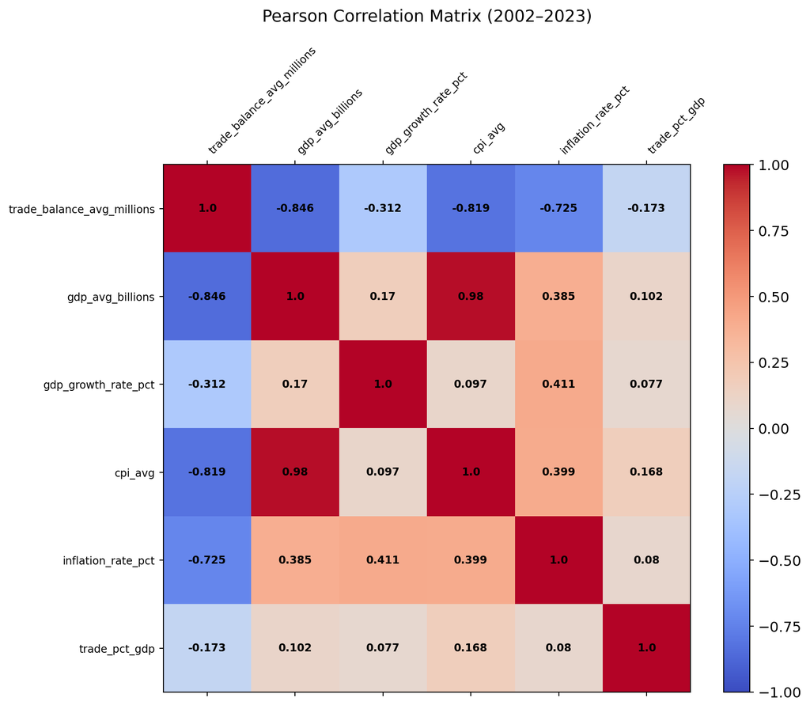

Figure 1: Pearson Correlation Heatmap (2002–2023)

```python
fig = plt.figure(figsize=(10, 8))
plt.matshow(corr_matrix, fignum=fig.number, cmap='coolwarm', vmin=-1, vmax=1)
cb = plt.colorbar()
cb.ax.tick_params(labelsize=12)
plt.title('Pearson Correlation Matrix (2002–2023)', fontsize=14, pad=20)
plt.xticks(range(len(corr_matrix.columns)), corr_matrix.columns, rotation=45, ha='left', fontsize=9)
plt.yticks(range(len(corr_matrix.columns)), corr_matrix.columns, fontsize=9)
for x in range(len(corr_matrix.columns)):
    for y in range(len(corr_matrix.columns)):
        plt.text(y, x, f"{corr_matrix.iloc[x, y]}",
                 ha='center', va='center', color='black', fontweight='bold', fontsize=9)
plt.tight_layout()
plt.show()
```

### 5.2 Linear Regression

We ran simple linear regression tests with trade balance as the independent variable and each macroeconomic indicator as the dependent variable.

```python
reg_df = merged_df.dropna(subset=['gdp_growth_rate_pct', 'inflation_rate_pct']).copy()

targets = [
    ('gdp_avg_billions',    'GDP (Billions USD)'),
    ('gdp_growth_rate_pct', 'GDP Growth Rate (%)'),
    ('inflation_rate_pct',  'Inflation Rate (%)'),
    ('trade_pct_gdp',       'Trade as % of GDP'),
]

results = []
for target_col, target_label in targets:
    slope, intercept, r_value, p_value, std_err = stats.linregress(
        reg_df['trade_balance_avg_millions'], reg_df[target_col]
    )
    results.append({
        'Dependent Variable': target_label,
        'Coefficient': round(slope, 5),
        'Intercept': round(intercept, 3),
        'R²': round(r_value**2, 4),
        'p-value': round(p_value, 4),
        'Significant': 'Yes' if p_value < 0.05 else 'No'
    })

pd.DataFrame(results)
```

Table 4: Linear Regression Results: Trade Balance as Predictor

|  | Dependent Variable | Coefficient | Intercept | R² | p-value | Significant |
| --- | --- | --- | --- | --- | --- | --- |
| 0 | GDP (Billions USD) | -0.13816 | 9096.549 | 0.7165 | 0.0000 | Yes |
| 1 | GDP Growth Rate (%) | -0.00004 | -0.409 | 0.0971 | 0.1581 | No |
| 2 | Inflation Rate (%) | -0.00009 | -3.157 | 0.5261 | 0.0001 | Yes |
| 3 | Trade as % of GDP | -0.00003 | 24.937 | 0.0298 | 0.4420 | No |

### 5.3 ANOVA Test

We divided the data into three time periods and tested whether the mean trade balance differed significantly across them using a one-way ANOVA.

```python
groups = [
    merged_df.loc[merged_df['period'] == p, 'trade_balance_avg_millions'].values
    for p in ['2002-2009', '2010-2019', '2020-2023']
]

f_stat, p_value = stats.f_oneway(*groups)

print(f"F-statistic: {f_stat:.4f}")
print(f"p-value:     {p_value:.4f}")
print(f"Result:      {'Statistically significant (p < 0.05)' if p_value < 0.05 else 'Not significant'}")

print("\nMean Trade Balance by Period:")
print(merged_df.groupby('period')['trade_balance_avg_millions'].mean().round(3))
```

Table 5: One-Way ANOVA: Trade Balance by Period

```
F-statistic: 14.8285
p-value:     0.0001
Result:      Statistically significant (p < 0.05)

Mean Trade Balance by Period:
period
2002-2009   -56928.386
2010-2019   -63568.917
2020-2023   -88085.980
Name: trade_balance_avg_millions, dtype: float64
```

### 5.4 Period Mean Comparisons

```python
period_means = (
    merged_df.groupby('period')[summary_cols]
    .mean()
    .round(3)
    .reindex(['2002-2009', '2010-2019', '2020-2023'])
)
period_means.T
```

Table 6: Mean Values by Time Period

| period | 2002-2009 | 2010-2019 | 2020-2023 |
| --- | --- | --- | --- |
| trade_balance_avg_millions | -56928.386 | -63568.917 | -88085.980 |
| gdp_avg_billions | 15889.241 | 18582.176 | 21654.139 |
| gdp_growth_rate_pct | 1.769 | 2.396 | 2.382 |
| cpi_avg | 198.345 | 237.113 | 281.790 |
| inflation_rate_pct | 2.439 | 1.770 | 4.513 |
| trade_pct_gdp | 25.577 | 28.556 | 25.404 |

## 6. Visualizations

### 6.1 Macroeconomic Trends Over Time

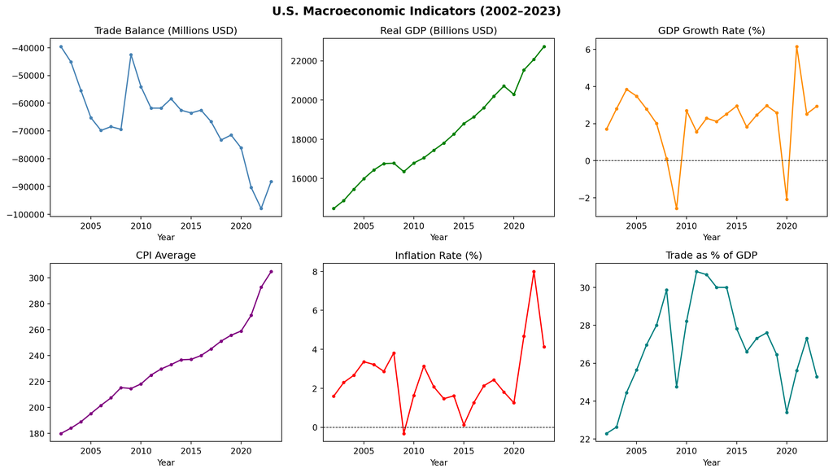

Figure 2: U.S. Macroeconomic Indicators (2002–2023)

```python
fig, axes = plt.subplots(2, 3, figsize=(14, 8))
fig.suptitle('U.S. Macroeconomic Indicators (2002–2023)', fontsize=14, fontweight='bold')

axes[0, 0].plot(merged_df['year'], merged_df['trade_balance_avg_millions'], color='steelblue', marker='o', markersize=3)
axes[0, 0].set_title('Trade Balance (Millions USD)')
axes[0, 0].set_xlabel('Year')

axes[0, 1].plot(merged_df['year'], merged_df['gdp_avg_billions'], color='green', marker='o', markersize=3)
axes[0, 1].set_title('Real GDP (Billions USD)')
axes[0, 1].set_xlabel('Year')

axes[0, 2].plot(merged_df['year'], merged_df['gdp_growth_rate_pct'], color='darkorange', marker='o', markersize=3)
axes[0, 2].axhline(0, color='black', linewidth=0.7, linestyle='--')
axes[0, 2].set_title('GDP Growth Rate (%)')
axes[0, 2].set_xlabel('Year')

axes[1, 0].plot(merged_df['year'], merged_df['cpi_avg'], color='purple', marker='o', markersize=3)
axes[1, 0].set_title('CPI Average')
axes[1, 0].set_xlabel('Year')

axes[1, 1].plot(merged_df['year'], merged_df['inflation_rate_pct'], color='red', marker='o', markersize=3)
axes[1, 1].axhline(0, color='black', linewidth=0.7, linestyle='--')
axes[1, 1].set_title('Inflation Rate (%)')
axes[1, 1].set_xlabel('Year')

axes[1, 2].plot(merged_df['year'], merged_df['trade_pct_gdp'], color='teal', marker='o', markersize=3)
axes[1, 2].set_title('Trade as % of GDP')
axes[1, 2].set_xlabel('Year')

plt.tight_layout()
plt.show()
```

### 6.2 Period Mean Comparisons

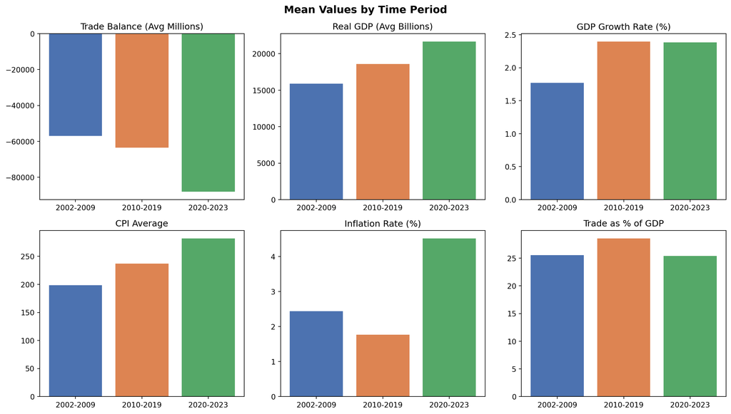

Figure 3: Mean Values by Time Period

```python
fig, axes = plt.subplots(2, 3, figsize=(14, 8))
fig.suptitle('Mean Values by Time Period', fontsize=14, fontweight='bold')
colors = ['#4C72B0', '#DD8452', '#55A868']

axes[0, 0].bar(period_means.index, period_means['trade_balance_avg_millions'], color=colors)
axes[0, 0].set_title('Trade Balance (Avg Millions)')

axes[0, 1].bar(period_means.index, period_means['gdp_avg_billions'], color=colors)
axes[0, 1].set_title('Real GDP (Avg Billions)')

axes[0, 2].bar(period_means.index, period_means['gdp_growth_rate_pct'], color=colors)
axes[0, 2].set_title('GDP Growth Rate (%)')

axes[1, 0].bar(period_means.index, period_means['cpi_avg'], color=colors)
axes[1, 0].set_title('CPI Average')

axes[1, 1].bar(period_means.index, period_means['inflation_rate_pct'], color=colors)
axes[1, 1].set_title('Inflation Rate (%)')

axes[1, 2].bar(period_means.index, period_means['trade_pct_gdp'], color=colors)
axes[1, 2].set_title('Trade as % of GDP')

plt.tight_layout()
plt.show()
```

### 6.3 Scatter Plots — Trade Balance vs Key Indicators

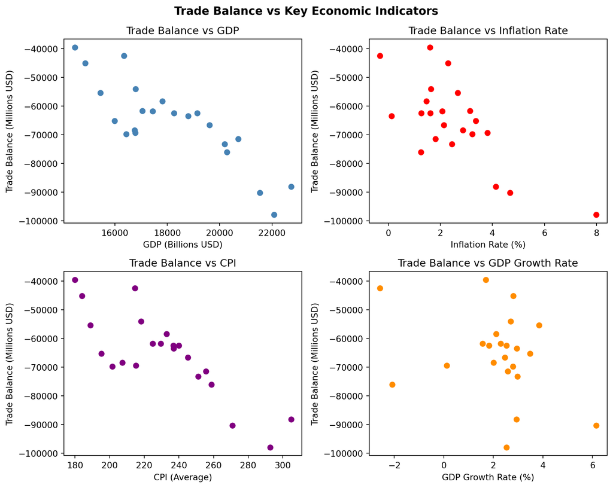

Figure 4: Trade Balance vs Key Economic Indicators

```python
fig, axes = plt.subplots(2, 2, figsize=(10, 8))
fig.suptitle('Trade Balance vs Key Economic Indicators', fontsize=13, fontweight='bold')

axes[0, 0].scatter(merged_df['gdp_avg_billions'], merged_df['trade_balance_avg_millions'], color='steelblue')
axes[0, 0].set_title('Trade Balance vs GDP')
axes[0, 0].set_xlabel('GDP (Billions USD)')
axes[0, 0].set_ylabel('Trade Balance (Millions USD)')

axes[0, 1].scatter(merged_df['inflation_rate_pct'], merged_df['trade_balance_avg_millions'], color='red')
axes[0, 1].set_title('Trade Balance vs Inflation Rate')
axes[0, 1].set_xlabel('Inflation Rate (%)')
axes[0, 1].set_ylabel('Trade Balance (Millions USD)')

axes[1, 0].scatter(merged_df['cpi_avg'], merged_df['trade_balance_avg_millions'], color='purple')
axes[1, 0].set_title('Trade Balance vs CPI')
axes[1, 0].set_xlabel('CPI (Average)')
axes[1, 0].set_ylabel('Trade Balance (Millions USD)')

axes[1, 1].scatter(merged_df['gdp_growth_rate_pct'], merged_df['trade_balance_avg_millions'], color='darkorange')
axes[1, 1].set_title('Trade Balance vs GDP Growth Rate')
axes[1, 1].set_xlabel('GDP Growth Rate (%)')
axes[1, 1].set_ylabel('Trade Balance (Millions USD)')

plt.tight_layout()
plt.show()
```

## 7. Discussion

The analysis revealed several important trends in the U.S. trade balance over time. Correlation results showed a strong negative relationship between the trade balance and GDP (-0.846) as well as CPI (-0.819), indicating that as the economy and price levels increased, the trade deficit tended to widen. Regression analysis further supported this, showing a statistically significant relationship between trade balance and GDP (R² = 0.7165, p < 0.05) and inflation (R² = 0.5261, p < 0.05), while GDP growth rate was not a significant predictor. Additionally, the ANOVA test confirmed that there are statistically significant differences in the trade balance across time periods (p = 0.0001). Mean comparisons showed that the trade deficit has worsened over time, with the average deficit increasing from about -56,928 million (2002–2009) to -88,086 million (2020–2023).

## 9. Individual Contributions

| Team Member | Roles |
| --- | --- |
| Kyle Tabong | Methodology, Software, Writing the Original Drafts |
| Taylor Hardesty | Data Curation, Visualization, Editing |
| Ashrutha Lingampalli | Formal Analysis, Data Cleaning/Merging, Resources |

### Kyle Tabong

- In the project proposal, my designated contributions were methodology, software,and writing the original draft, and these roles stayed consistent throughout the project. I was responsible for setting up the environment, choosing the necessary Python libraries, and writing data_ingestion.ipynb to pull all four datasets from their respective APIs. I also configured the Quarto manuscript and kept the shared GitHub repository organized for the team. Throughout this project I learned more about working with APIs that return data at different frequencies and how to account for limitations like mismatched date ranges when merging datasets.

### Taylor Hardesty

- In the project proposal, my designated contributions were data curation, formal analysis, and writing the original draft, but my role shifted as the project progressed. I ended up focusing on visualization, data validation, and review/editing, contributing to visuals using my prior experience and the want to focus on visualizations. Throughout the project I have learned many new data visualization techniques such as visualizing the corrolation matrix. I learned more about how to work with and read corrolation staisitics.

### Ashrutha Lingampalli

- In the project proposal, I was initially responsible for creating visualizations, but my role shifted to being responsible for the data cleaning/merging and conducting the formal analysis. This was done after re-discussing our roles again and being more attentive to what aspect we each wanted to learn more about. Throughout this project I learned more about data cleaning techniques and how to handle limitations such as the dataset being restricted to the years 2002 to 2023 due to differences in data availability across sources.

## 10. Track B Reflection

In our proposal, we stated: “The value of the project comes from finding useful insights by stitching together data sources that have not previously been analyzed together in a single study… we take a broader macroeconomic lens, looking at GDP and inflation correlations across the full U.S. economy.” After completing the project, this statement was mostly accurate. We were able to successfully combine data from multiple sources and analyze relationships between trade balance, GDP, and inflation, which provided meaningful insights into long-term economic trends. The distinction in our approach still holds as in our analysis the variables we focused on macro-level patterns in GDP, CPI, Inflation, GDP Growth Rate, rather than domestic employment. We were able to see a negative correlation between the trade balance average in millions and the GDP average in billions. In our research using the same data we were able to derive more insight to relationships using a broader macroeconomic focus.

## References

Federal Reserve Bank of St. Louis. (2024). *Federal Reserve Economic Data (FRED)*. Retrieved from https://fred.stlouisfed.org/docs/api/fred/

Robert C. Feenstra, Hong Ma, and Yuan Xu, “US Exports and Employment,” *NBER Working Paper 24056* (2017), https://doi.org/10.3386/w24056.*

World Bank Group. (2024). *World Bank Open Data*. Retrieved from https://datahelpdesk.worldbank.org/knowledgebase/articles/889392